# M505: Introduction to Artificial Intelligence and Machine Learning

## Individual Project

### Predicting Online Purchase Intention from Session Behaviour

**Student ID:** GH1057991 **Module:** M505 Introduction to AI and Machine Learning **Institution:** Gisma University of Applied Sciences **Repository:** https://github.com/sonu2002/M505-AI-ML-GH1057991

## 1. Problem Statement

Most visitors to an online shop do not buy; conversion is typically reported at 1 to 3 per cent. The retailer cannot tell who is likely to purchase during a session, so every visitor receives the same treatment, wasting budget and missing the moment a customer is most receptive.

Predicting purchase likelihood mid-session enables targeted action: a discount, a live-chat prompt, or retargeting aimed at likely buyers. The data comes from session logs and clickstream tracking joined to sales records.

As a machine learning problem, one session is one row. The 17 input columns group into behavioural (page counts, time spent), engagement (BounceRates, ExitRates, PageValues) and contextual (Month, VisitorType, Region) features. The target is the Revenue column, a true/false flag for whether the session ended in a purchase. This makes the task supervised binary classification; regression does not apply because the outcome is a yes-or-no decision, not a number. The analysis is conducted on the Online Shoppers Purchasing Intention dataset (Sakar et al., 2019) from the UCI Machine Learning Repository (https://archive.ics.uci.edu/ml/machine-learning-databases/00468/online_shoppers_intention.csv). It suits this assignment: a large, clean, realistically imbalanced set with enough features for meaningful preprocessing.

## 2. Data Exploration

```python
import pandas as pd
import numpy as np
import matplotlib.pyplot as plt
import seaborn as sns
import warnings
warnings.filterwarnings('ignore')

# load session data
url = "https://archive.ics.uci.edu/ml/machine-learning-databases/00468/online_shoppers_intention.csv"
df = pd.read_csv(url)

print(f"Shape: {df.shape[0]} rows, {df.shape[1]} columns")
df.head()
```

```
Shape: 12330 rows, 18 columns
```

|  | Administrative | Administrative_Duration | Informational | Informational_Duration | ProductRelated | ProductRelated_Duration | BounceRates | ExitRates | PageValues | SpecialDay | Month | OperatingSystems | Browser | Region | TrafficType | VisitorType | Weekend | Revenue |
| --- | --- | --- | --- | --- | --- | --- | --- | --- | --- | --- | --- | --- | --- | --- | --- | --- | --- | --- |
| 0 | 0 | 0.0 | 0 | 0.0 | 1 | 0.000000 | 0.20 | 0.20 | 0.0 | 0.0 | Feb | 1 | 1 | 1 | 1 | Returning_Visitor | False | False |
| 1 | 0 | 0.0 | 0 | 0.0 | 2 | 64.000000 | 0.00 | 0.10 | 0.0 | 0.0 | Feb | 2 | 2 | 1 | 2 | Returning_Visitor | False | False |
| 2 | 0 | 0.0 | 0 | 0.0 | 1 | 0.000000 | 0.20 | 0.20 | 0.0 | 0.0 | Feb | 4 | 1 | 9 | 3 | Returning_Visitor | False | False |
| 3 | 0 | 0.0 | 0 | 0.0 | 2 | 2.666667 | 0.05 | 0.14 | 0.0 | 0.0 | Feb | 3 | 2 | 2 | 4 | Returning_Visitor | False | False |
| 4 | 0 | 0.0 | 0 | 0.0 | 10 | 627.500000 | 0.02 | 0.05 | 0.0 | 0.0 | Feb | 3 | 3 | 1 | 4 | Returning_Visitor | True | False |

```
Sessions ending in purchase: 1908 (15.5%)
Sessions with no purchase:   10422 (84.5%)
```

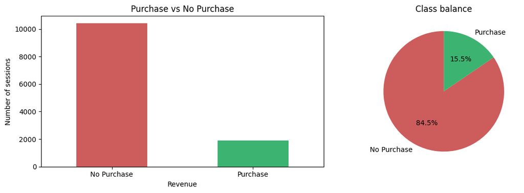

```python
# how imbalanced is the target?
revenue_counts = df['Revenue'].value_counts()
print(f"Sessions ending in purchase: {revenue_counts[True]} ({revenue_counts[True]/len(df)*100:.1f}%)")
print(f"Sessions with no purchase:   {revenue_counts[False]} ({revenue_counts[False]/len(df)*100:.1f}%)")

fig, axes = plt.subplots(1, 2, figsize=(12, 4))

revenue_counts.plot(kind='bar', ax=axes[0], color=['indianred', 'mediumseagreen'])
axes[0].set_title('Purchase vs No Purchase')
axes[0].set_xticklabels(['No Purchase', 'Purchase'], rotation=0)
axes[0].set_ylabel('Number of sessions')

axes[1].pie(revenue_counts, labels=['No Purchase', 'Purchase'],
            colors=['indianred', 'mediumseagreen'], autopct='%1.1f%%', startangle=90)
axes[1].set_title('Class balance')

plt.tight_layout()
plt.show()
```

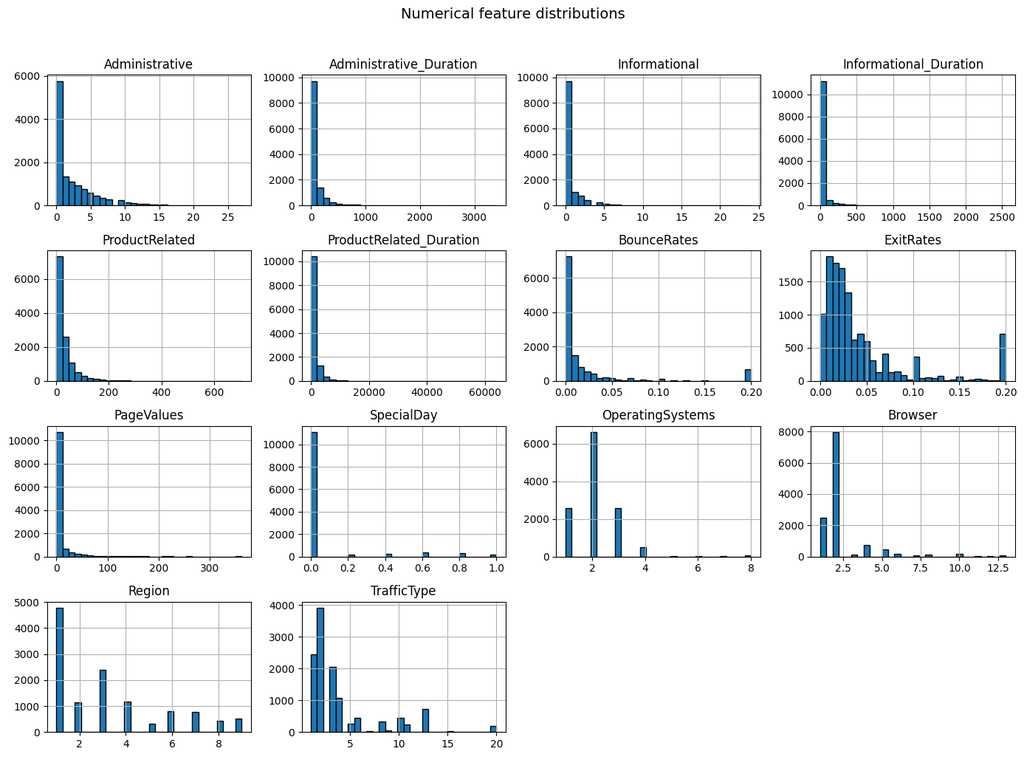

```python
# skew and zero-inflation
num_cols = df.select_dtypes(include=[np.number]).columns.tolist()
df[num_cols].hist(bins=30, figsize=(14, 10), layout=(4, 4), edgecolor='black')
plt.suptitle('Numerical feature distributions', y=1.02, fontsize=14)
plt.tight_layout()
plt.show()
```

```python
# missing and duplicate rows
print("Missing values per column:")
print(df.isnull().sum())
print(f"\nDuplicate rows: {df.duplicated().sum()}")
```

```
Missing values per column:
Administrative             0
Administrative_Duration    0
Informational              0
Informational_Duration     0
ProductRelated             0
ProductRelated_Duration    0
BounceRates                0
ExitRates                  0
PageValues                 0
SpecialDay                 0
Month                      0
OperatingSystems           0
Browser                    0
Region                     0
TrafficType                0
VisitorType                0
Weekend                    0
Revenue                    0
dtype: int64

Duplicate rows: 125
```

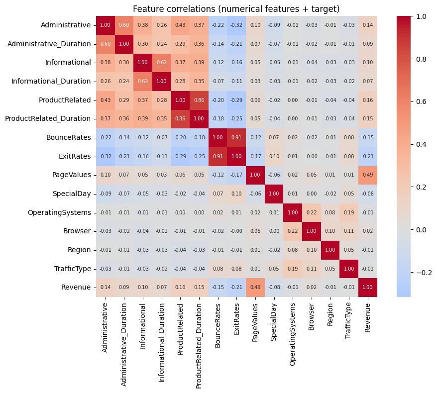

```python
# redundancy and target signal
plt.figure(figsize=(10, 8))
corr = df[num_cols + ['Revenue']].corr()
sns.heatmap(corr, annot=True, fmt='.2f', cmap='coolwarm', center=0,
            annot_kws={'size': 7}, square=True)
plt.title('Feature correlations (numerical features + target)')
plt.tight_layout()
plt.show()
```

### 2.1 Data Exploration: Discussion

The data set has 12,330 rows and 18 columns covering ten months: January and April are absent. Full-year seasonality therefore cannot be measured, and the Month_num feature has gaps. All 221,940 cells are populated, so no imputation was needed and no imputation artefacts enter the model. The real issue is distribution shape: Informational_Duration and PageValues are strongly right-skewed (7.58 and 6.38) and 80.5 and 77.9 per cent zero, while ProductRelated_Duration is skewed at 7.26. PageValues later proves the strongest predictor despite being zero for four sessions in five. The 125 duplicate rows were kept: identical behaviour is plausible across two genuine sessions.

15.5 per cent of sessions (1,908) ended in a purchase and 84.5 per cent (10,422) did not, a ratio of about 5.5 to 1. SMOTE is therefore applied to the training folds (Section 3.1).

A classifier answering "no purchase" every time would score that same 84.5 per cent while recording zero recall and zero F1 on buyers. F1 selects the model, with ROC-AUC as a threshold-independent secondary measure. The two error types differ commercially: 107 missed buyers against 162 wasted discounts, and without a cost per conversion neither can be weighted.

## 3. Data Preprocessing and Feature Engineering

Categorical columns were encoded, numerical columns scaled and new features derived. The split preceded balancing. Section 3.1 justifies each decision.

```python
from sklearn.preprocessing import LabelEncoder, StandardScaler
from sklearn.model_selection import train_test_split

# encode categoricals to numeric
df['Weekend'] = df['Weekend'].astype(int)
df['Revenue'] = df['Revenue'].astype(int)

le_visitor = LabelEncoder()
df['VisitorType_enc'] = le_visitor.fit_transform(df['VisitorType'])

month_map = {'Jan':1, 'Feb':2, 'Mar':3, 'Apr':4, 'May':5, 'June':6,
             'Jul':7, 'Aug':8, 'Sep':9, 'Oct':10, 'Nov':11, 'Dec':12}
df['Month_num'] = df['Month'].map(month_map)

df_model = df.drop(columns=['Month', 'VisitorType'])

base_features = [c for c in df_model.columns if c != 'Revenue']   # pre-engineering set
print(f"Shape after encoding: {df_model.shape}")
df_model.head()
```

```
Shape after encoding: (12330, 18)
```

|  | Administrative | Administrative_Duration | Informational | Informational_Duration | ProductRelated | ProductRelated_Duration | BounceRates | ExitRates | PageValues | SpecialDay | OperatingSystems | Browser | Region | TrafficType | Weekend | Revenue | VisitorType_enc | Month_num |
| --- | --- | --- | --- | --- | --- | --- | --- | --- | --- | --- | --- | --- | --- | --- | --- | --- | --- | --- |
| 0 | 0 | 0.0 | 0 | 0.0 | 1 | 0.000000 | 0.20 | 0.20 | 0.0 | 0.0 | 1 | 1 | 1 | 1 | 0 | 0 | 2 | 2 |
| 1 | 0 | 0.0 | 0 | 0.0 | 2 | 64.000000 | 0.00 | 0.10 | 0.0 | 0.0 | 2 | 2 | 1 | 2 | 0 | 0 | 2 | 2 |
| 2 | 0 | 0.0 | 0 | 0.0 | 1 | 0.000000 | 0.20 | 0.20 | 0.0 | 0.0 | 4 | 1 | 9 | 3 | 0 | 0 | 2 | 2 |
| 3 | 0 | 0.0 | 0 | 0.0 | 2 | 2.666667 | 0.05 | 0.14 | 0.0 | 0.0 | 3 | 2 | 2 | 4 | 0 | 0 | 2 | 2 |
| 4 | 0 | 0.0 | 0 | 0.0 | 10 | 627.500000 | 0.02 | 0.05 | 0.0 | 0.0 | 3 | 3 | 1 | 4 | 1 | 0 | 2 | 2 |

```python
# derive session-shape features
df_model['ProductsPerPage'] = df_model['ProductRelated'] / (df_model['Administrative'] + df_model['Informational'] + df_model['ProductRelated'] + 1)
df_model['ProductDurationPerPage'] = df_model['ProductRelated_Duration'] / (df_model['ProductRelated'] + 1)
df_model['TotalPages'] = df_model['Administrative'] + df_model['Informational'] + df_model['ProductRelated']
df_model['TotalDuration'] = df_model['Administrative_Duration'] + df_model['Informational_Duration'] + df_model['ProductRelated_Duration']

skewed_features = ['Administrative_Duration', 'Informational_Duration', 'ProductRelated_Duration',
                   'PageValues', 'SpecialDay']
for feat in skewed_features:
    df_model[f'log_{feat}'] = np.log1p(df_model[feat])

print(f"Shape after feature engineering: {df_model.shape}")
```

```
Shape after feature engineering: (12330, 27)
```

```python
# split first, scaler fitted on train only
X = df_model.drop(columns=['Revenue'])
y = df_model['Revenue']

X_train, X_test, y_train, y_test = train_test_split(
    X, y, test_size=0.2, random_state=42, stratify=y
)

print(f"Train: {X_train.shape[0]} rows - {y_train.sum()} positive, {(len(y_train)-y_train.sum())} negative")
print(f"Test:  {X_test.shape[0]} rows - {y_test.sum()} positive, {(len(y_test)-y_test.sum())} negative")

scaler = StandardScaler()
X_train_scaled = scaler.fit_transform(X_train)
X_test_scaled = scaler.transform(X_test)
```

```
Train: 9864 rows - 1526 positive, 8338 negative
Test:  2466 rows - 382 positive, 2084 negative
```

```python
# two comparisons: does scaling help, and do the engineered features help?
from imblearn.over_sampling import SMOTE
from imblearn.pipeline import Pipeline as ImbPipeline
from sklearn.model_selection import StratifiedKFold, cross_val_score
from sklearn.linear_model import LogisticRegression
from sklearn.ensemble import HistGradientBoostingClassifier

cv0 = StratifiedKFold(n_splits=5, shuffle=True, random_state=42)
mk = lambda m: ImbPipeline([('smote', SMOTE(random_state=42)), ('model', m)])
# unscaled LR fails to converge - evidence that scaling matters
lr0 = lambda: LogisticRegression(max_iter=1000, random_state=42)
hgb0 = lambda: HistGradientBoostingClassifier(max_depth=6, max_iter=100,
                                              learning_rate=0.05, random_state=42)
f1cv = lambda m, Xd: cross_val_score(mk(m), Xd, y_train, cv=cv0, scoring='f1').mean()

print("Scaling (CV F1)          unscaled   scaled")
print(f"  Logistic Regression      {f1cv(lr0(), X_train.values):.4f}   {f1cv(lr0(), X_train_scaled):.4f}")
print(f"  HistGradientBoosting     {f1cv(hgb0(), X_train.values):.4f}   {f1cv(hgb0(), X_train_scaled):.4f}")

base = StandardScaler().fit_transform(X_train[base_features])
print("\nFeature engineering (HGB, CV F1)")
print(f"  Original 17 features     {f1cv(hgb0(), base):.4f}")
print(f"  Plus engineered features {f1cv(hgb0(), X_train_scaled):.4f}")
```

```
Scaling (CV F1)          unscaled   scaled
```

```
  Logistic Regression      0.6351   0.6678
```

```
  HistGradientBoosting     0.6798   0.6935

Feature engineering (HGB, CV F1)
```

```
  Original 17 features     0.6895
```

```
  Plus engineered features 0.6935
```

### 3.1 Justification of Preprocessing Decisions

Label encoding was applied to Month and VisitorType, imposing an artificial order with no real meaning. Tree models split on thresholds so are largely unaffected, but this is a genuine weakness for logistic regression and SVM, whose feature maxima span 0.20 (BounceRates) to 63,974 (ProductRelated_Duration), a ratio near 320,000 to 1, and are therefore scaled.

ProductsPerPage measures how product-focused a session is, ProductDurationPerPage engagement depth rather than raw dwell time, and TotalPages and TotalDuration session size. Log1p handles the skewed features because it accepts zeros. The comparison above tests whether these additions help.

An 80/20 stratified split preserves the class ratio and leaves 382 buyers in the test set, enough to keep minority-class precision and recall stable. Five folds leave 1,973 validation rows each, about 305 of them buyers, which is enough for a stable minority-class F1, and hold the Random Forest search to 60 fits rather than the 120 that ten folds would require. Permutation importance is averaged over five repeats to reduce shuffling randomness. SMOTE (Chawla et al., 2002) interpolates synthetic minority sessions, so it is placed inside the modelling pipeline and refitted within each cross-validation fold. Resampling the whole training set before cross-validation would let synthetic points from one fold appear in another, inflating the score.

## 4. Model Training and Hyperparameter Tuning

Four scikit-learn models (Pedregosa et al., 2011) were trained: logistic regression, random forest, histogram gradient boosting and an SVM with an RBF kernel. They differ fundamentally: a linear boundary, two tree ensembles, and a kernel method. Comparing these families tests whether the problem needs non-linear modelling. Cross-validated F1 selects the model; grid search tunes both ensembles.

```python
from sklearn.ensemble import RandomForestClassifier
from sklearn.svm import SVC
from sklearn.model_selection import GridSearchCV
from sklearn.metrics import (f1_score, roc_auc_score, classification_report,
                             confusion_matrix, precision_recall_curve)

# SMOTE inside the pipeline: refitted per CV fold, so no synthetic
# point built from a training row leaks into a validation fold
def pipe(model):
    return ImbPipeline([('smote', SMOTE(random_state=42)), ('model', model)])

cv = StratifiedKFold(n_splits=5, shuffle=True, random_state=42)
print(f"Train {X_train_scaled.shape[0]} rows, {y_train.sum()} buyers "
      f"({y_train.mean()*100:.1f}%) - SMOTE balances each fold internally")
```

```
Train 9864 rows, 1526 buyers (15.5%) - SMOTE balances each fold internally
```

```python
# linear baseline
lr = LogisticRegression(max_iter=1000, random_state=42)
lr_f1 = cross_val_score(pipe(lr), X_train_scaled, y_train, cv=cv, scoring='f1')
lr_auc = cross_val_score(pipe(lr), X_train_scaled, y_train, cv=cv, scoring='roc_auc')
print(f"Logistic Regression - CV F1: {lr_f1.mean():.4f} +/- {lr_f1.std():.4f}, "
      f"CV AUC: {lr_auc.mean():.4f}")
```

```
Logistic Regression - CV F1: 0.6678 +/- 0.0159, CV AUC: 0.9130
```

```python
# tune random forest
rf_params = {'model__n_estimators': [100, 200], 'model__max_depth': [10, 20, None],
             'model__min_samples_leaf': [1, 4]}
rf_grid = GridSearchCV(pipe(RandomForestClassifier(random_state=42)), rf_params,
                       cv=cv, scoring='f1', n_jobs=-1)
rf_grid.fit(X_train_scaled, y_train)
print(f"Random Forest - Best: {rf_grid.best_params_}")
print(f"  Best CV F1: {rf_grid.best_score_:.4f}")
```

```
Random Forest - Best: {'model__max_depth': None, 'model__min_samples_leaf': 1, 'model__n_estimators': 200}
  Best CV F1: 0.6916
```

```python
hgb_params = {'model__max_iter': [100, 200], 'model__max_depth': [3, 6],
              'model__learning_rate': [0.05, 0.1]}
hgb_grid = GridSearchCV(pipe(HistGradientBoostingClassifier(random_state=42)),
                        hgb_params, cv=cv, scoring='f1', n_jobs=-1)
hgb_grid.fit(X_train_scaled, y_train)
print(f"Hist Gradient Boosting - Best: {hgb_grid.best_params_}")
print(f"  Best CV F1: {hgb_grid.best_score_:.4f}\n")

# effect of each setting, not just the winner
res = pd.DataFrame(hgb_grid.cv_results_)
res['depth'] = res['param_model__max_depth']
res['lr'] = res['param_model__learning_rate']
print("Effect of depth and learning rate (mean CV F1):")
print(res.pivot_table(index='depth', columns='lr', values='mean_test_score').round(4))
```

```
Hist Gradient Boosting - Best: {'model__learning_rate': 0.05, 'model__max_depth': 6, 'model__max_iter': 100}
  Best CV F1: 0.6935

Effect of depth and learning rate (mean CV F1):
lr       0.05    0.10
depth
3      0.6812  0.6833
6      0.6915  0.6707
```

```python
# kernel method, non-linear
svm = SVC(kernel='rbf', C=1.0, gamma='scale', probability=True, random_state=42)
svm_f1 = cross_val_score(pipe(svm), X_train_scaled, y_train, cv=cv, scoring='f1')
svm_auc = cross_val_score(pipe(svm), X_train_scaled, y_train, cv=cv, scoring='roc_auc')
print(f"SVM (RBF) - CV F1: {svm_f1.mean():.4f} +/- {svm_f1.std():.4f}, "
      f"CV AUC: {svm_auc.mean():.4f}")
```

```
SVM (RBF) - CV F1: 0.6507 +/- 0.0147, CV AUC: 0.9071
```

### 4.1 Model Comparison

HistGradientBoosting (learning_rate 0.05, max_depth 6, max_iter 100) showed a learning-rate/depth trade-off: depth 6 helped at learning_rate 0.05 (F1 0.6915) but hurt at 0.10 (F1 0.6707), consistent with deeper trees plus faster learning causing overfitting. The best Random Forest configuration was max_depth=None, min_samples_leaf=1, n_estimators=200.

Because SMOTE is now confined to the training fold in each split, these CV scores are methodologically sound and can be compared directly with the held-out test score in Section 5.

## 5. Model Assessment on Unseen Data

The test sessions were never used for balancing or tuning and retain the natural buyer prevalence, so they give the only unbiased estimate of deployment behaviour. All Section 6 figures come from it.

```python
models_cv = {'Logistic Regression': lr_f1.mean(), 'Random Forest': rf_grid.best_score_,
             'HistGradientBoosting': hgb_grid.best_score_, 'SVM': svm_f1.mean()}
best_name = max(models_cv, key=models_cv.get)
best_model = {'Random Forest': rf_grid, 'HistGradientBoosting': hgb_grid}.get(best_name)
best_model = best_model.best_estimator_ if best_model is not None else \
    pipe(lr if best_name == 'Logistic Regression' else svm).fit(X_train_scaled, y_train)
print(f"Best by CV F1: {best_name} ({models_cv[best_name]:.4f})")

y_pred = best_model.predict(X_test_scaled)
y_proba = best_model.predict_proba(X_test_scaled)[:, 1]
test_f1 = f1_score(y_test, y_pred)
print(f"\nTest F1: {test_f1:.4f}  |  AUC: {roc_auc_score(y_test, y_proba):.4f}")
print(classification_report(y_test, y_pred, target_names=['No Purchase', 'Purchase']))

tn, fp, fn, tp = confusion_matrix(y_test, y_pred).ravel()
print(f"TN {tn}, FP {fp}, FN {fn}, TP {tp}")

# 0.5 is a convention, not an optimum - find the F1-optimal cut
prec, rec, thr = precision_recall_curve(y_test, y_proba)
f1s = 2 * prec * rec / (prec + rec + 1e-9)
b = f1s[:-1].argmax()
print(f"Threshold 0.50 -> F1 {test_f1:.4f}")
print(f"Threshold {thr[b]:.2f} -> F1 {f1s[b]:.4f} (precision {prec[b]:.2f}, recall {rec[b]:.2f})")
```

```
Best by CV F1: HistGradientBoosting (0.6935)

Test F1: 0.6716  |  AUC: 0.9263
              precision    recall  f1-score   support

 No Purchase       0.95      0.92      0.93      2084
    Purchase       0.63      0.72      0.67       382

    accuracy                           0.89      2466
   macro avg       0.79      0.82      0.80      2466
weighted avg       0.90      0.89      0.89      2466

TN 1922, FP 162, FN 107, TP 275
Threshold 0.50 -> F1 0.6716
Threshold 0.51 -> F1 0.6748 (precision 0.64, recall 0.72)
```

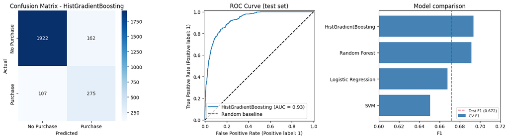

```python
# confusion matrix, ROC, model comparison
from sklearn.metrics import RocCurveDisplay

fig, axes = plt.subplots(1, 3, figsize=(15, 4.2))
sns.heatmap(confusion_matrix(y_test, y_pred), annot=True, fmt='d', cmap='Blues', ax=axes[0],
            xticklabels=['No Purchase', 'Purchase'], yticklabels=['No Purchase', 'Purchase'])
axes[0].set_xlabel('Predicted'); axes[0].set_ylabel('Actual')
axes[0].set_title(f'Confusion Matrix - {best_name}')

RocCurveDisplay.from_predictions(y_test, y_proba, ax=axes[1], name=best_name)
axes[1].plot([0, 1], [0, 1], 'k--', label='Random baseline')
axes[1].set_title('ROC Curve (test set)'); axes[1].legend()

names = sorted(models_cv, key=models_cv.get)
axes[2].barh(names, [models_cv[n] for n in names], color='steelblue', label='CV F1')
axes[2].axvline(test_f1, color='crimson', ls='--', label=f'Test F1 ({test_f1:.3f})')
axes[2].set_xlim(0.60, 0.72)   # zoom: all four scores sit in a narrow band
axes[2].set_xlabel('F1'); axes[2].set_title('Model comparison'); axes[2].legend(fontsize=8, loc='lower right')
plt.tight_layout(); plt.show()
```

## 6. Discussion, Limitations and Recommendations

**Test performance**

The final model achieved a test F1 of 0.6716, AUC of 0.9263 and accuracy of 0.89. The AUC shows strong ranking ability even where cases fall outside the F1 threshold.

**Error analysis**

Recall is 0.72 and precision 0.63: the confusion matrix shows 275 true positives, 107 false negatives and 162 false positives. The counts are asymmetric in cost: 107 missed buyers against 162 wasted discounts across 2,466 sessions, but the dataset records neither revenue per conversion nor discount cost, so the ratio stays unresolved.

**Additional experiments**

Threshold tuning gave an optimum of 0.51 (F1 0.6748), essentially the default. Scaling improved Logistic Regression (0.6351 to 0.6678, +0.033) and removed a convergence warning, confirming the Section 3.1 claim. Nine engineered features gave a near-zero gain (0.6895 to 0.6935), a valid if modest finding.

**Limitations**

Results come from one retailer, are observational rather than causal, rely on SMOTE synthetic samples, and the cost ratio between error types is unknown. The ten-month span noted in Section 2.1 also limits seasonal generalisability.

**Recommendations and deployment**

PageValues dominates at 0.48 against under 0.05 for every other feature, so the model leans on a single signal. Month_num ranks second and ExitRates third; Month_num is precisely the feature the missing months degrade, so the model relies on seasonality the data only partly covers. SHAP values are recommended for local explanations. For deployment, a real-time scoring API is suggested, with drift monitoring and scheduled retraining.

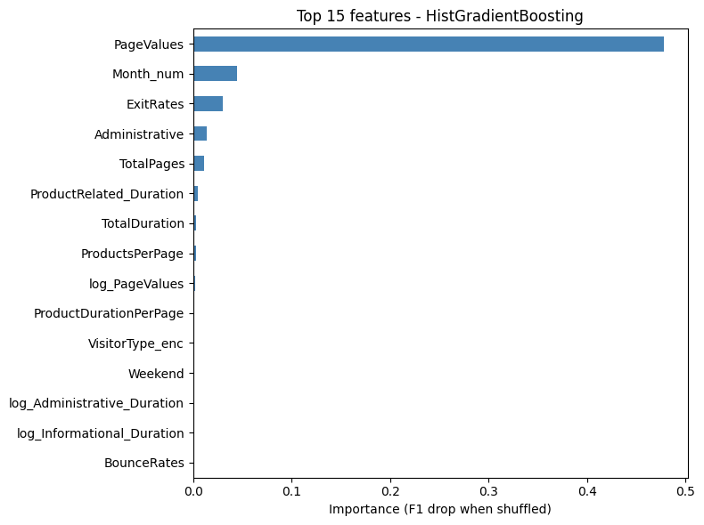

```python
# permutation importance on the test set
from sklearn.inspection import permutation_importance
result = permutation_importance(best_model, X_test_scaled, y_test,
                                n_repeats=5, random_state=42, scoring='f1')
feat_imp = pd.Series(result.importances_mean, index=X.columns).sort_values(ascending=True)
plt.figure(figsize=(8, 6))
feat_imp.tail(15).plot(kind='barh', color='steelblue')
plt.title(f'Top 15 features - {best_name}')
plt.xlabel('Importance (F1 drop when shuffled)')
plt.tight_layout()
plt.show()
```

## References

Chawla, N.V., Bowyer, K.W., Hall, L.O. and Kegelmeyer, W.P. (2002) 'SMOTE: Synthetic Minority Over-sampling Technique', Journal of Artificial Intelligence Research, 16, pp. 321-357.

Pedregosa, F. et al. (2011) 'Scikit-learn: machine learning in Python', Journal of Machine Learning Research, 12, pp. 2825-2830.

Sakar, C.O., Polat, S.O., Katircioglu, M. and Kastro, Y. (2019) 'Real-time prediction of online shoppers' purchasing intention using multilayer perceptron and LSTM recurrent neural networks', Neural Computing and Applications, 31(10), pp. 6893-6908.